# Exploratory Data Analysis

Boris Beranger & Maeve McGillycuddy

November, 2024

# The steps involved in a Statistical Analysis

- What data to collect? This depends on what the research question is and who asks it.
- How to collect data in a clever way? Design of experiments, computer simulations.
- How to organize your data? In paper notebooks? files? data bases?
- How to describe your data? File format and size. File content. Statistical descriptive summaries.
- How to analyse data? Relationships, statistical inference

A dataset is a collection of data (i.e., numbers, qualifiers, pieces of information) that usually come from actual observations collected on cases, obtained by sampling a population.

Each row corresponds to the observations (values) of a few variables (e.g., height or weight) on one given element (case) of that population. Each column represents a particular variable.

The data set may comprise data for one or more members, corresponding to the number of rows, and called the sample size.

You should clearly identify the:

- Population: the collection of all individuals or items or objects under consideration in a statistical study, usually determined by what we want to know.
- Cases: the members, objects, units, subjects or individuals from the population, from which information (i.e., data) is collected.
- IDs: the identification code of each case.
- Sample: a subset of the population.
- Sample size, $n$: number of cases/observations in the sample.
- Variable: a characteristic of the cases (measured, collected, recorded or counted).
- Number of variables, $p$: the total number of variable.

# The *MATH1041 - Statistics for Life and Social Science* Class Survey

First year students taking the MATH1041 course were asked several questions. The answers to those taking the course in Term 1, 2024 were collated into a dataset which we are now loading into R and displaying the first six rows.

```r
load("data/MATH1041-2024T1.RData")
head(survey.df)
```

```
##                 Department gender age birth.month day.you day.bro day.mum
## 1 School of Health Science Female  43       April      25       3       4
## 2              Engineering   Male  23     October      31      19       4
## 3                 Business Female  22     January      15      19      10
## 4                  Science Female  NA        July      17       1       4
## 5                 Business Female  22      August       5      11      11
## 6                 Business   Male  22       March       5      17      31
##   day.dad hemisphere study.area outside.work     stress hours.sleep coffee
## 1       9   Southern   Medicine            1  Extremely           6      0
## 2      21   Southern    Science            0       Very           8      0
## 3      17              Business            1       Very           7      0
## 4      10   Southern    Science           NA   Slightly           5      3
## 5       4   Southern   Business            1 Moderately           7      1
## 6      15   Southern    Science            0 Not at all           3      1
##   unsw.satisfaction flu facebook.friends facebook.time gym fruits.vegetables
## 1              4.00  15               50             2 360                 5
## 2              2.00   7              700             5   3                 6
## 3              2.50  10              271             2 160                 4
## 4              5.00   2                0             0  NA                NA
## 5              4.50   4              961             1 450                 2
## 6              1.61   0             1451             2 240                 2
##   hair.cost tennis.tv survey.finished                     Major    sex
## 1        50         1               1       Exercise Physiology Female
## 2        20         1               1                   Ecology   Male
## 3        90         1               1                 MARKETING Female
## 4       395         0              NA                           Female
## 5       600         0               1 Human Resource Management Female
## 6        25         1               1               Mathematics   Male
```

- Population?
- Cases?
- IDs?
- Sample size?
- Number of variables?
- Name of variables?

```r
dim(survey.df) # dimension of the dataset
```

```
## [1] 209  25
```

```r
nrow(survey.df) # number of rows in the dataset
```

```
## [1] 209
```

```r
ncol(survey.df) # number of columns in the dataset
```

```
## [1] 25
```

```r
names(survey.df) # names of columns in the dataset
```

```
##  [1] "Department"        "gender"            "age"
##  [4] "birth.month"       "day.you"           "day.bro"
##  [7] "day.mum"           "day.dad"           "hemisphere"
## [10] "study.area"        "outside.work"      "stress"
## [13] "hours.sleep"       "coffee"            "unsw.satisfaction"
## [16] "flu"               "facebook.friends"  "facebook.time"
## [19] "gym"               "fruits.vegetables" "hair.cost"
## [22] "tennis.tv"         "survey.finished"   "Major"
## [25] "sex"
```

# Random Variables

The type of a variable is either categorical or quantitative.

- A qualitative or categorical variable places an individual into one of several categories.
- A quantitative variable takes numerical values, for which arithmetic operations such as averaging make sense.

We dissociate two types of quantitative random variables:

- Discrete random variables can take only distinct, separate values.
- Continuous random variables can take any values in some interval (low, high)

**Let’s decide what type of variables are in the MATH1041 survey dataset.** If needed type `survey.df$variablename` or simply `variablename` to see the values the variables takes.

```r
survey.df$Department
```

```
##   [1] School of Health Science       Engineering
##   [3] Business                       Science
##   [5] Business                       Business
##   [7] Science                        Science
##   [9] Engineering                    Science
##  [11] School of Psychology           Business
##  [13] Science                        Science
##  [15] Science                        Science
##  [17] Business                       Science
##  [19] Science                        Science
##  [21] Science                        Business
##  [23] Science                        Business
##  [25] School of Psychology           Sch of Economics
##  [27] Science                        Science
##  [29] Biological, Earth & Env Sci    Science
```

[output cut: 91 more lines]

**`Department`**

qualitative

**`gender`**

qualitative

**`age`**

quantitative, discrete

**`birth.month`**

qualitative

**`day.you`**

qualitative

**`day.bro`**

qualitative

**`day.mum`**

qualitative

**`day.dad`**

qualitative

**`hemisphere`**

qualitative

**`study.area`**

qualitative

**`outside.work`**

qualitative

**`stress`**

qualitative

**`hours.sleep`**

quanitative, continuous

**`coffee`**

quantitative, discrete

**`unsw.satisfaction`**

quantitative, continuous

**`flu`**

quantitative, discrete

**`facebook.friends`**

quantitative, continuous

**`gym`**

quantitative, discrete

**`fruit.vegetables`**

quantitative, discrete

**`hair.cost`**

quantitative, continuous

**`tennis.tv`**

qualitative

**`survey.finished`**

qualitative

**`Major`**

qualitative

**`Sex`**

qualitative

# Numerical summaries for one variable

## Numerical summaries for a categorical variable

We can summarise one categorical variable using table of frequencies which corresponds to a list of the possible categories (even those not observed) together with their counts, percent or proportion of cases in each category.

Consider the survey question *“Did you watch the Australian Open Women Tennis Final (yes/no)?”*, a table of frequencies is produced as follows

```r
table(tennis.tv)
```

```
## tennis.tv
##   0   1
## 153  56
```

If we wanted percentages, we would use

```r
prop.table(table(tennis.tv)) * 100
```

```
## tennis.tv
##        0        1
## 73.20574 26.79426
```

and if we wanted both counts and percentages to be displayed

```r
tbl <- table(tennis.tv)
cbind(tbl, prop.table(tbl) * 100)
```

```
##   tbl
## 0 153 73.20574
## 1  56 26.79426
```

## Numerical summaries for a quantitative variable

Is it a good idea to compute a table of frequencies or percentages for a quantitative variable? Why? Why not?

When summarising a **quantitative** variable numerically, we often make sure to include measures of:

- the location (where most of the data are), and
- the spread (or variability) of the data.

A useful measure of the location is the mean which mathematically, if let $\boldsymbol{x}= \{ x_1, \ldots, x_n \}$ represent the $n$ observations (the data points), is calculated as:
$$\textrm{mean}(\boldsymbol{x}) = \frac{x_1 +
\cdots + x_n}{n}.$$
An alternative to the mean is the median, it corresponds to the *middle value*. If we sort the observations into $x_{(1)} \leq \cdots \leq x_{(n)}$, the median is computed as
$$\textrm{median}(\boldsymbol{x}) =
x_{(n+1)/2} \textrm{ if } n \textrm{ is odd} \quad \textrm{and} \quad
\textrm{median}(\boldsymbol{x}) = \frac{1}{2}\left( x_{n/2} +
x_{(n+1)/2}\right) \textrm{ if } n \textrm{ is even.}$$

WARNING *The mean can be grossly affected by unusually large (or small) data values that tend to be quite far away from the bulk of the data.*

In R, the `mean()` and `median()` functions, as their name indicate, calculate the mean and median values from a vector of observations.

Use these functions to calculate the mean and median of the UNSW satisfaction score.

```r
mean(unsw.satisfaction)
```

```
## [1] 4.507703
```

```r
median(unsw.satisfaction)
```

```
## [1] 4.5
```

The median splits the data into two groups which contain roughly $50\%$ of the data.

Quartiles divide the data into four groups which each contain roughly $25\%$ (a quarter) of the data. $Q_1$ and $Q_3$ are known as the first and third quantile. $Q_2$ is just the median.

A useful measure for spread could be the Inter-quartiles range (IQR).

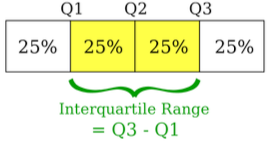

Quartiles and inter-quartile range

Other useful measures are the standard deviation $\textrm{sd}(\boldsymbol{x})$ and the variance $\textrm{var}(\boldsymbol{x}) = \textrm{sd}(\boldsymbol{x})^2$. We voluntarily omit the mathematical expressions, we will use R to calculate them directly.

In R, the `quantile(x=..., probs=...)` function computes the quantiles of a vector given in `x` with probability `probs`. For example, $Q_1$ is found by selecting `probs=0.25`. The standard deviation and variance are respectively computed using the `sd()` and `var()` functions.

Use these functions to calculate the IQR, standard deviation and variance of the UNSW satisfaction score.

```r
diff(quantile(unsw.satisfaction, c(0.25, 0.75)))
```

```
## 75%
##   1
```

```r
c( sd(unsw.satisfaction), sd(unsw.satisfaction)^2, var(unsw.satisfaction))
```

```
## [1] 1.038383 1.078239 1.078239
```

Another useful function is `summary()`, which gives the following 5-number summary

```r
summary(unsw.satisfaction)
```

```
##    Min. 1st Qu.  Median    Mean 3rd Qu.    Max.
##   1.610   4.000   4.500   4.508   5.000   8.000
```

# Graphical summaries for one variable

## Graphical summaries for a categorical variable

**Bar charts** are used to summarise **categorical** random variables. In R, this is done using the `barplot()` function and below is an example with the `tennis.tv` variable.

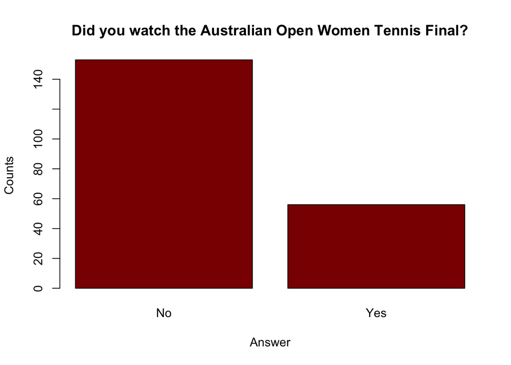

```r
barplot(table(tennis.tv),
        names.arg=c("No", "Yes"),
        main="Did you watch the Australian Open Women Tennis Final?",
        xlab="Answer", ylab="Counts",col="darkred")
```

The above plot was done in base R, now let’s be fancy and use `ggplot`! We require to load the `ggplot2` library (and install it if needed).

```r
#install.packages("ggplot2")
library(ggplot2)
```

We start by creating a `data.frame` object as follows

```r
tennis <- data.frame(answer=c("No", "Yes"), count=as.vector(tbl))
tennis
```

```
##   answer count
## 1     No   153
## 2    Yes    56
```

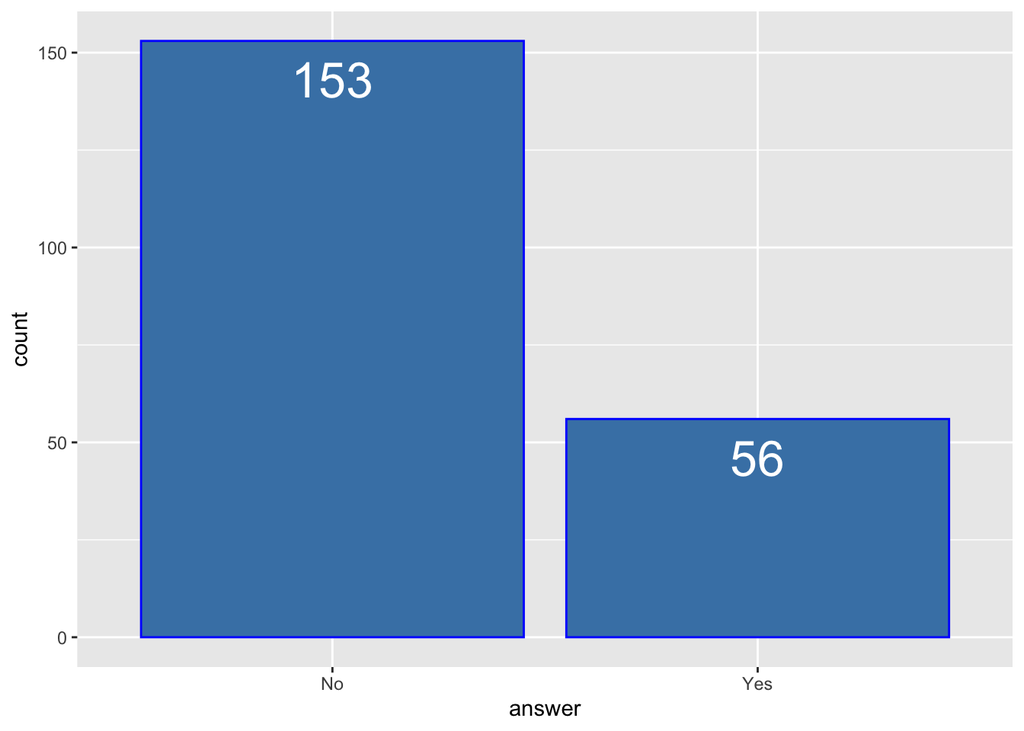

```r
p <- ggplot(data=tennis, aes(x=answer, y=count)) +
            geom_bar(stat="identity", color="blue",fill="steelblue") +
            geom_text(aes(label=count), vjust=1.6, color="white", size=8.5)
p
```

Take the time to play with the arguments to see what each of them does.

We could improve the plot further by, for example, doing the following

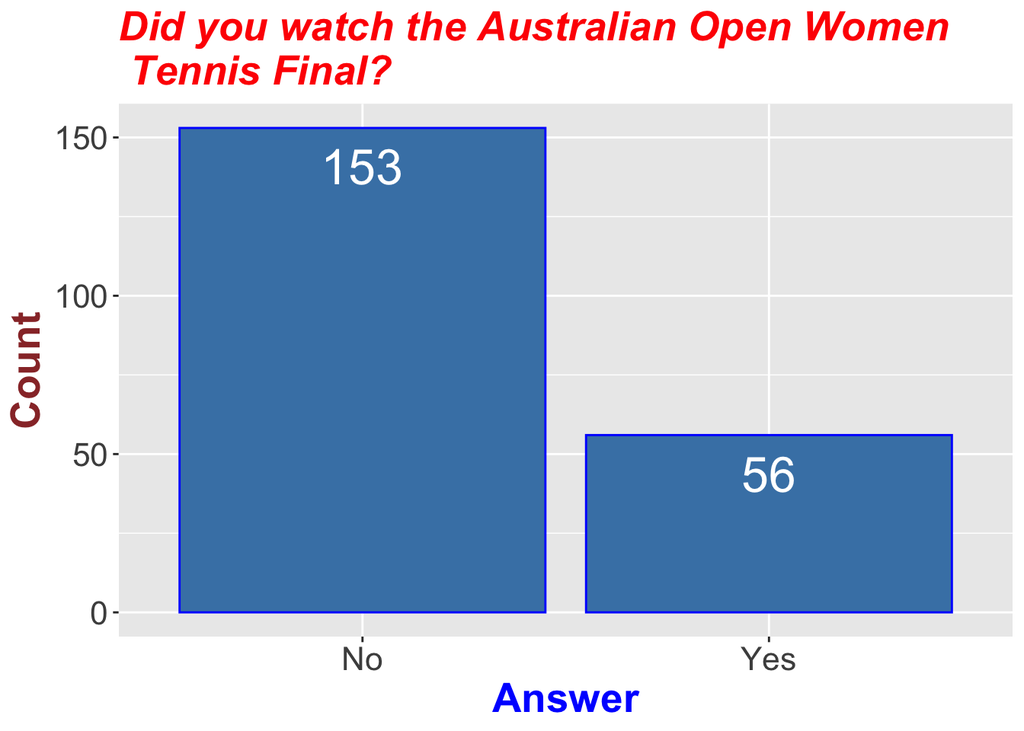

```r
p +
  ggtitle("Did you watch the Australian Open Women \n Tennis Final?") +
  xlab("Answer") +
  ylab("Count") +
  theme(plot.title = element_text(color="red", size=20, face="bold.italic"),
        axis.text = element_text(size=16),
        axis.title.x = element_text(color="blue", size=20, face="bold"),
        axis.title.y = element_text(color="#993333", size=20, face="bold"))
```

## Graphical summaries for a quantitative variable

**Boxplots** and **Histograms** are used to summarise **quantitative** random variables. In R, the corresponding functions are `boxplot()` and `hist()`. Below is an example applied to the UNSW satisfaction score, using the `ggplot2` library.

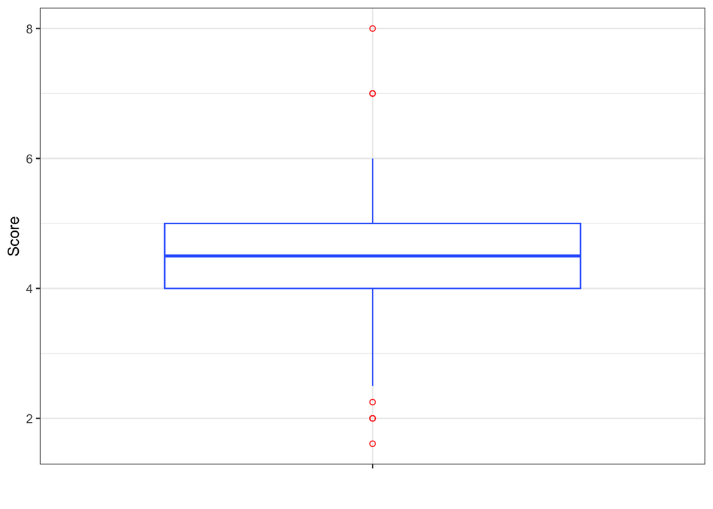

```r
sat <- data.frame(satisfaction = unsw.satisfaction)
p2 <- ggplot(data=sat, aes(x="", y=satisfaction)) +
             geom_boxplot(fill = "white", colour = "#3366FF",
                          outlier.colour = "red", outlier.shape = 1) +
             ylab("Score") +
             xlab("") +
             theme_bw()
p2
```

Note: the length of the whiskers is by default 1.5 times IQR, the argument `coef` in `geom_boxplot()` controls that value.

Once again, take the time to play with the arguments to see what each of them does.

We could super-impose the data points to the plot

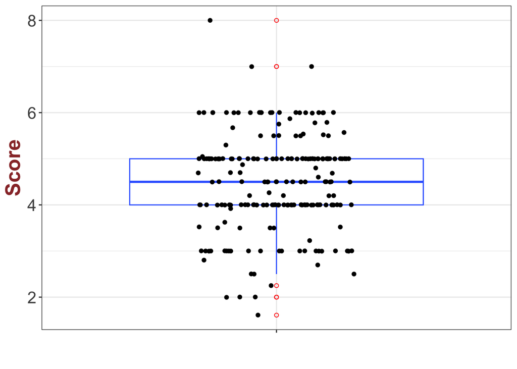

```r
p2 + geom_jitter(width = 0.2) +
     theme(axis.text = element_text(size=16),
           axis.title.y = element_text(color="#993333", size=20, face="bold"))
```

… and now plotting a histogram

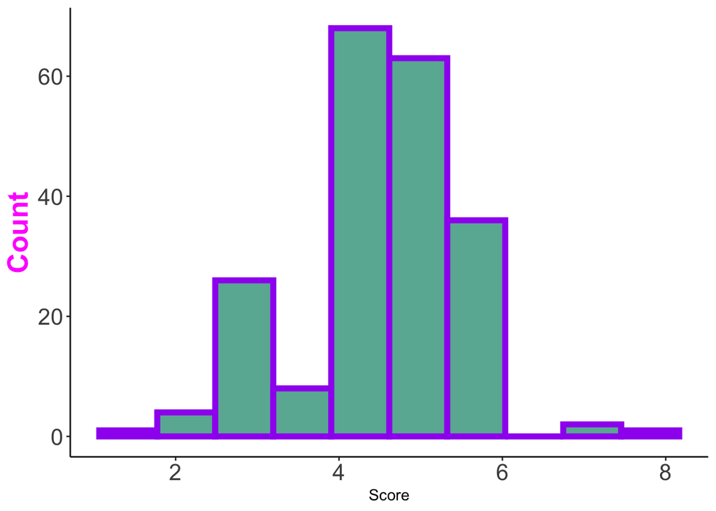

```r
p3 <- ggplot(data=sat, aes(satisfaction)) +
             geom_histogram(fill = "#69b3a2", colour = "purple", bins=10, linewidth=2) +
             xlab("Score") +
             ylab("Count") +
             theme_classic() +
             theme(axis.text = element_text(size=16),
                   axis.title.y = element_text(color="magenta", size=20, face="bold"))
p3
```

# Numerical summaries for two variables

## Numerical summaries for two categorical variables

In this case we use a **2-way table of frequencies**, which we compute using the `table()` function, like when we add only one variable. Let’s consider the variables `sex` and `stress` which we have agreed to be categorical.

```r
table(sex, stress)
```

```
##         stress
## sex      Not at all Slightly Moderately Very Extremely
##   Male            9       24         23    9         3
##   Female          9       38         61   18        10
```

Adding proportions:

```r
tbl2 <- table(sex, stress)
round(prop.table(tbl2, margin =2),3) # for column
```

```
##         stress
## sex      Not at all Slightly Moderately  Very Extremely
##   Male        0.500    0.387      0.274 0.333     0.231
##   Female      0.500    0.613      0.726 0.667     0.769
```

```r
round(prop.table(tbl2, margin =1),3) # for row
```

```
##         stress
## sex      Not at all Slightly Moderately  Very Extremely
##   Male        0.132    0.353      0.338 0.132     0.044
##   Female      0.066    0.279      0.449 0.132     0.074
```

For fancier table see e.g., `tabyl()`.

## Numerical summaries for one categorical and one quantitative variable

Here we compute a **5-number summary for each group/category**.

```r
summary(hair.cost[sex=="Female"])
```

```
##    Min. 1st Qu.  Median    Mean 3rd Qu.    Max.    NA's
##     0.0    30.0    55.0   102.9   122.5   600.0       5
```

```r
summary(hair.cost[sex=="Male"])
```

```
##    Min. 1st Qu.  Median    Mean 3rd Qu.    Max.    NA's
##     0.0    15.0    25.0    56.3    30.0  2000.0       5
```

# Graphical summaries for two variables

## Graphical summaries for two categorical variables

When we have two categorical variables, we use a **clustered bar chart**. The `ggplot2` library makes this kind of plot easy, and in this case we use the `geom_bar()` function.

Again, we start by creating a `data.frame` object.

```r
SS <- data.frame(stress=rep(colnames(tbl2), each=2),
                 sex = c(rep(rownames(tbl2), 5)),
                 count=as.vector(tbl2))
SS
```

```
##        stress    sex count
## 1  Not at all   Male     9
## 2  Not at all Female     9
## 3    Slightly   Male    24
## 4    Slightly Female    38
## 5  Moderately   Male    23
## 6  Moderately Female    61
## 7        Very   Male     9
## 8        Very Female    18
## 9   Extremely   Male     3
## 10  Extremely Female    10
```

and then proceed to plot

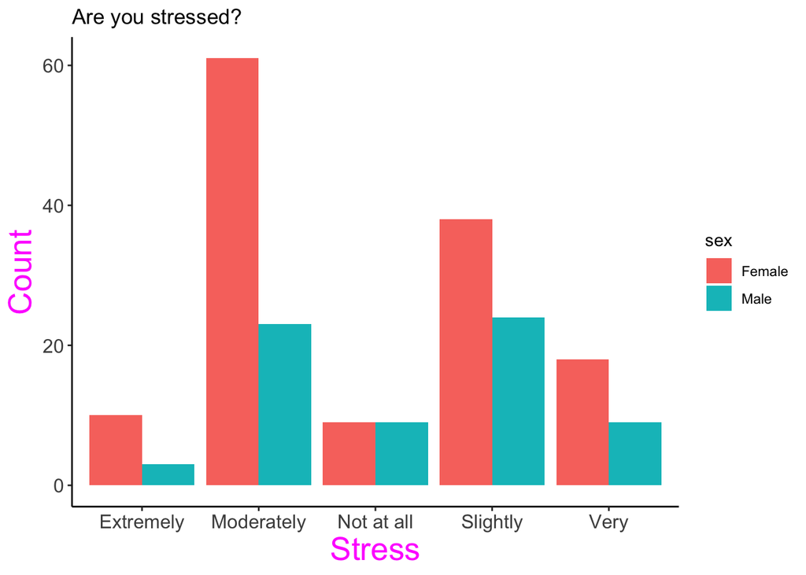

```r
p4 <- ggplot(data=SS, aes(x=stress, y=count, fill=sex)) +
             geom_bar(stat="identity", position="dodge") +
             ggtitle("Are you stressed?") +
             ylab("Count") +
             xlab("Stress") +
             theme_classic() +
             theme(axis.text = element_text(size=12),
                   axis.title = element_text(color="magenta", size=20))
p4
```

## Graphical summaries for one categorical and one quantitative variable

In that case, we use **comparative boxplots**. Following the previous examples, it is fairly straightforward to do such plots with `ggplot2`.

We create a `data.frame` object …

```r
SH <- data.frame(sex=sex, hair.cost=hair.cost)
SH
```

```
##        sex hair.cost
## 1   Female     50.00
## 2     Male     20.00
## 3   Female     90.00
## 4   Female    395.00
## 5   Female    600.00
## 6     Male     25.00
## 7     Male    100.00
## 8   Female     10.00
## 9     Male     90.00
## 10  Female     80.00
## 11  Female    100.00
## 12    Male     30.00
## 13    Male     35.00
## 14  Female      6.00
```

[output cut: 195 more lines]

… and plot!

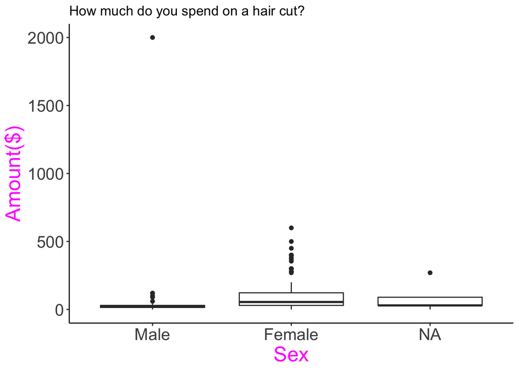

```r
p5 <- ggplot(data=SH, aes(x=sex, y=hair.cost)) +
             geom_boxplot() +
             ggtitle("How much do you spend on a hair cut?") +
             ylab("Amount($)") +
             xlab("Sex") +
             theme_classic() +
             theme(axis.text = element_text(size=16),
                   axis.title = element_text(color="magenta", size=20))
p5
```

**Do you see anything funny/crazy??**

Let’s re-do this plot and remove the observation with the largest cost for a haircut.

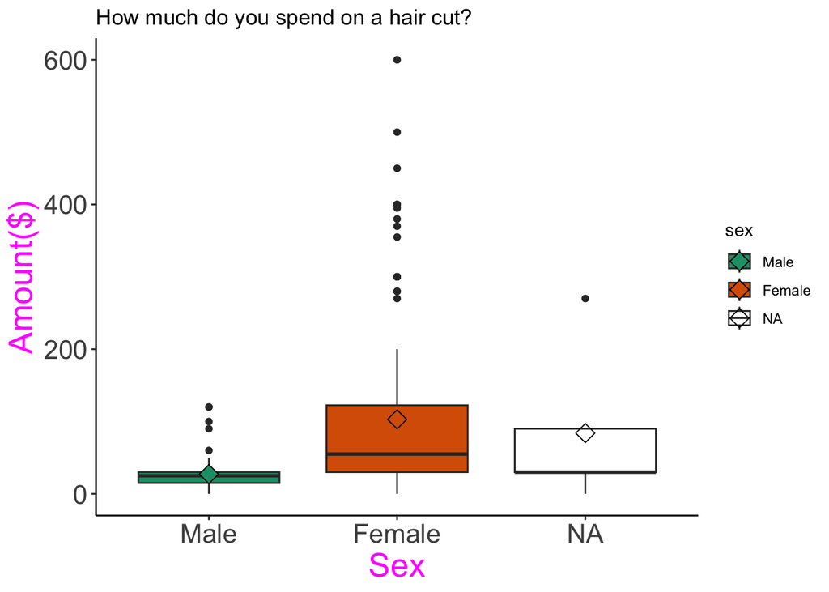

```r
p5 <- ggplot(data=SH[-which.max(hair.cost),], aes(x=sex, y=hair.cost, fill=sex)) +
             geom_boxplot() +
             ggtitle("How much do you spend on a hair cut?") +
             ylab("Amount($)") +
             xlab("Sex") +
             scale_fill_brewer(palette="Dark2") +
             theme_classic() +
             theme(axis.text = element_text(size=16),
                   axis.title = element_text(color="magenta", size=20))
p5 + stat_summary(fun=mean, geom="point", shape=23, size=4) # adding means
```

## Graphical summaries with two quantitative variables

The easiest way to display **two quantitative random variables** is via a **scatterplot**. Below we use the `geomm_point()` function to plot the average number of hours of sleep per night (`hours.slept`) as a function of age (`age`).

```r
AH <- data.frame(age=age, hours=hours.sleep)
head(AH, 10)
```

```
##    age hours
## 1   43     6
## 2   23     8
## 3   22     7
## 4   NA     5
## 5   22     7
## 6   22     3
## 7   NA     7
## 8   21     7
## 9   NA     6
## 10  21     7
```

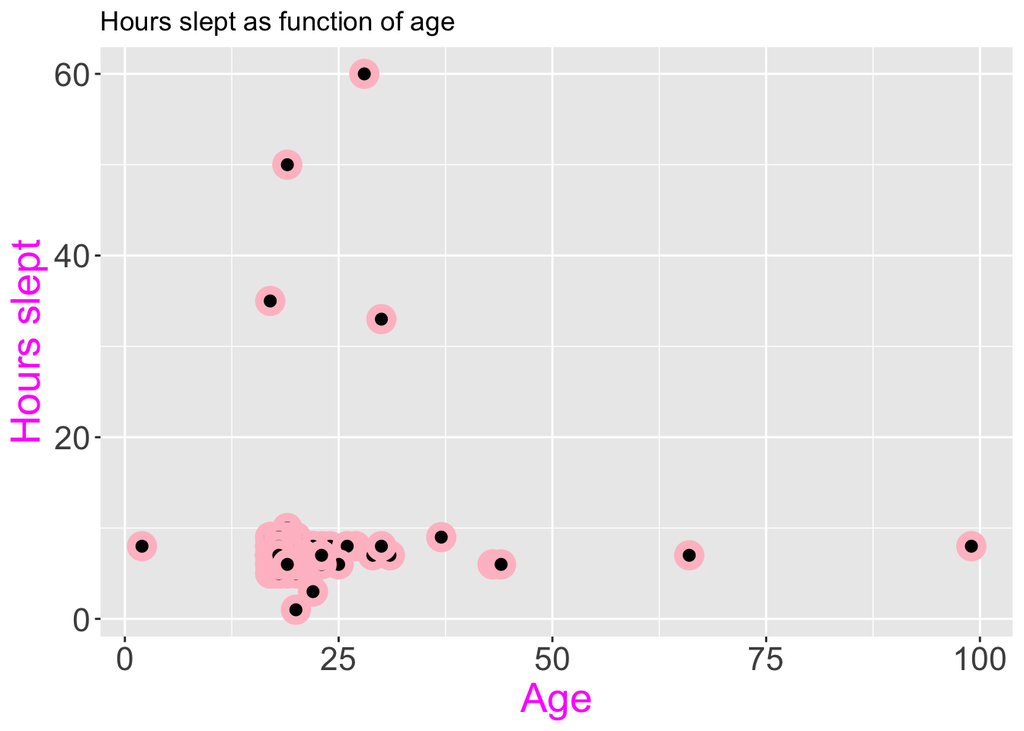

```r
p6 <- ggplot(data=AH, aes(x=age, y=hours.sleep)) +
             ggtitle("Hours slept as function of age") +
             ylab("Hours slept") +
             xlab("Age") +
             theme(axis.text = element_text(size=16),
                   axis.title = element_text(color="magenta", size=20))
p6 + geom_point(shape = 21, colour = "pink", fill = "black", size = 3, stroke = 3)
```

Once again, take the time to play with the arguments to see what each of them does.

We can change the type of point in the scatterplot **as a function of a third, categorical, variable**.

```r
AH$sex <- sex
head(AH,10)
```

```
##    age hours    sex
## 1   43     6 Female
## 2   23     8   Male
## 3   22     7 Female
## 4   NA     5 Female
## 5   22     7 Female
## 6   22     3   Male
## 7   NA     7   Male
## 8   21     7 Female
## 9   NA     6   Male
## 10  21     7 Female
```

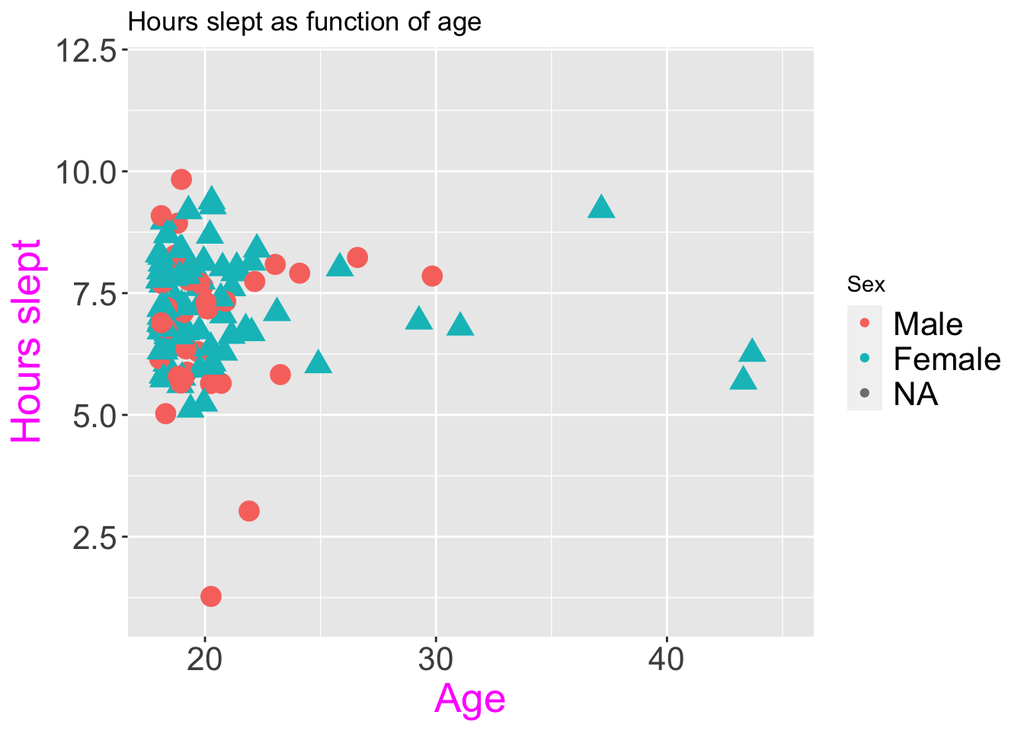

```r
p6 + geom_jitter(aes(shape=factor(sex), colour = factor(sex), size=2)) +
     scale_x_continuous(limits = c(18, 45)) +
     scale_y_continuous(limits = c(1, 12)) +
     scale_colour_discrete("Sex") +
     guides(size = "none", shape = "none") +
     theme(legend.text = element_text(size=16))
```

## Numerical summaries with two quantitative variables

**Correlation** is a special form of dependence (association) **between two quantitative variables**. The correlation coefficient is a number that measures the association between two quantities, indicating the strength and the direction of the linear statistical relationship between the variables.

We denote the (Pearson) Coefficient of correlation by $r$ and for any data set
$$-1 \leq r \leq 1.$$
It is interpreted as follows:

- $r$ close to 1 $\Leftrightarrow$ strong positive linear relationship.
- $r$ close to -1 $\Leftrightarrow$ strong negative linear relationship.
- $r$ close to 0 $\Leftrightarrow$ weak or non-existent linear relationship.

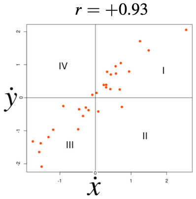

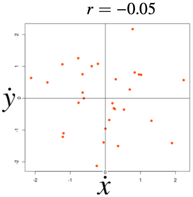

Examples of correlation between two variables

In R, the correlation between two variables, say `x` and `y` is computed using `cor(x,y)`. If the variables are stored in the same object (a `matrix` or a `data.frame`), then providing the column indicator is sufficient. E.g., `cor(mat[,1:2])`.

Look at the scatterplot of the average number of hours of sleep per night and age, what is your guess for the correlation between these two variables? Use R to check your intuition.

```r
cor(AH[,1:2]) # Same as cor(AH[,1], AH[,1]) . Both produces NA!!!
```

```
##       age hours
## age     1    NA
## hours  NA     1
```

```r
cor(na.omit(AH)[,1:2])
```

```
##              age      hours
## age   1.00000000 0.07026975
## hours 0.07026975 1.00000000
```

# Summary of the different numerical/graphical summaries

The table below provides a summary of which tool to use when providing numerical and/or graphical summaries of one or more variables

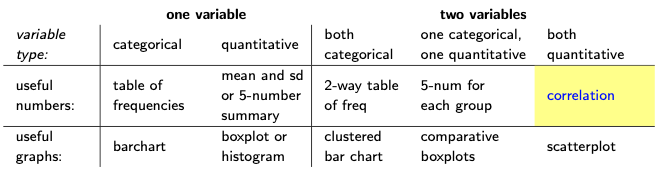

Summary of summaries!

# TL;DR - Code

**Toggle to see all of the code**

```r
  load("data/MATH1041-2024T1.RData")
  head(survey.df)
  dim(survey.df) # dimension of the dataset
  nrow(survey.df) # number of rows in the dataset
  nrow(survey.df) # number of rows in the dataset
  survey.df$Department
  table(tennis.tv)
  prop.table(table(tennis.tv)) * 100 #percentages
  tbl <- table(tennis.tv)
  cbind(tbl, prop.table(tbl) * 100)
  # Numerical summaries for a quantitative variable
  mean(unsw.satisfaction)
  median(unsw.satisfaction)
  diff(quantile(unsw.satisfaction, c(0.25, 0.75)))
  c( sd(unsw.satisfaction), sd(unsw.satisfaction)^2, var(unsw.satisfaction))
  c( sd(unsw.satisfaction), sd(unsw.satisfaction)^2, var(unsw.satisfaction))
  # Graphical summaries
  barplot(table(tennis.tv),
        names.arg=c("No", "Yes"),
        main="Did you watch the Australian Open Women Tennis Final?",
        xlab="Answer", ylab="Counts",col="darkred")
  library(ggplot2)
  tennis <- data.frame(answer=c("No", "Yes"), count=as.vector(tbl))
  p <- ggplot(data=tennis, aes(x=answer, y=count)) +
            geom_bar(stat="identity", color="blue",fill="steelblue") +
            geom_text(aes(label=count), vjust=1.6, color="white", size=8.5)
  p +
  ggtitle("Did you watch the Australian Open Women \n Tennis Final?") +
  xlab("Answer") +
  ylab("Count") +
  theme(plot.title = element_text(color="red", size=20, face="bold.italic"),
        axis.text = element_text(size=16),
        axis.title.x = element_text(color="blue", size=20, face="bold"),
        axis.title.y = element_text(color="#993333", size=20, face="bold"))

  sat <- data.frame(satisfaction = unsw.satisfaction)
  p2 <- ggplot(data=sat, aes(x="", y=satisfaction)) +
             geom_boxplot(fill = "white", colour = "#3366FF",
                          outlier.colour = "red", outlier.shape = 1) +
             ylab("Score") +
             xlab("") +
             theme_bw()
  p2 + geom_jitter(width = 0.2) +
     theme(axis.text = element_text(size=16),
           axis.title.y = element_text(color="#993333", size=20, face="bold"))
           p2 + geom_jitter(width = 0.2) +
     theme(axis.text = element_text(size=16),
           axis.title.y = element_text(color="#993333", size=20, face="bold"))
  # Numerical summaries for two categorical variables
  table(sex, stress)
  tbl2 <- table(sex, stress)
  round(prop.table(tbl2, margin =2),3) # for column
  round(prop.table(tbl2, margin =1),3) # for row
  summary(hair.cost[sex=="Female"])
  summary(hair.cost[sex=="Female"])
  # Graphical summaries for two categorical variables
  SS <- data.frame(stress=rep(colnames(tbl2), each=2),
                 sex = c(rep(rownames(tbl2), 5)),
                 count=as.vector(tbl2))

  p4 <- ggplot(data=SS, aes(x=stress, y=count, fill=sex)) +
             geom_bar(stat="identity", position="dodge") +
             ggtitle("Are you stressed?") +
             ylab("Count") +
             xlab("Stress") +
             theme_classic() +
             theme(axis.text = element_text(size=12),
                   axis.title = element_text(color="magenta", size=20))

  SH <- data.frame(sex=sex, hair.cost=hair.cost)

  p5 <- ggplot(data=SH, aes(x=sex, y=hair.cost)) +
             geom_boxplot() +
             ggtitle("How much do you spend on a hair cut?") +
             ylab("Amount($)") +
             xlab("Sex") +
             theme_classic() +
             theme(axis.text = element_text(size=16),
                   axis.title = element_text(color="magenta", size=20))

  p5 <- ggplot(data=SH[-which.max(hair.cost),], aes(x=sex, y=hair.cost, fill=sex)) +
             geom_boxplot() +
             ggtitle("How much do you spend on a hair cut?") +
             ylab("Amount($)") +
             xlab("Sex") +
             scale_fill_brewer(palette="Dark2") +
             theme_classic() +
             theme(axis.text = element_text(size=16),
                   axis.title = element_text(color="magenta", size=20))
  p5 + stat_summary(fun=mean, geom="point", shape=23, size=4) # adding means

  AH <- data.frame(age=age, hours=hours.sleep)
  head(AH, 10)
  p6 <- ggplot(data=AH, aes(x=age, y=hours.sleep)) +
             ggtitle("Hours slept as function of age") +
             ylab("Hours slept") +
             xlab("Age") +
             theme(axis.text = element_text(size=16),
                   axis.title = element_text(color="magenta", size=20))
  p6 + geom_point(shape = 21, colour = "pink", fill = "black", size = 3, stroke = 3)

  AH$sex <- sex
  head(AH,10)

  p6 + geom_jitter(aes(shape=factor(sex), colour = factor(sex), size=2)) +
     scale_x_continuous(limits = c(18, 45)) +
     scale_y_continuous(limits = c(1, 12)) +
     scale_colour_discrete("Sex") +
     guides(size = "none", shape = "none") +
     theme(legend.text = element_text(size=16))

  # Numerical summaries with two quantitative variables
  cor(AH[,1:2]) # Same as cor(AH[,1], AH[,1]) . Both produces NA!!!
  cor(na.omit(AH)[,1:2])
```